# project5_report.rmd

Creating data from digital sources

Hadas Livne

2024-05-22

## Part A

I explored data relating to the popularity and progression of the media format of online interactive stories. I used Sufficient Velocity, a “quest” forum site that is popular for this format, for this purpose. I selected this data context because I am very interested in the ways in which free, self-published online literature develops, as I think it gives real insight into human nature and community surrounding producing art - specifically writing - for the fun of it and it is often dismissed in research contexts because it’s of non-publisher quality or less high brow than published literature.

```r
library(tidyverse)
library(rvest)


# My data context is the popularity and progression of the media format of online interactive stories.
# Information that may be useful to scrape for such purposes would be the numbers and stats of a wide variety of such stories, in order to compare them.
# Such stats may include 'likes', word counts, dates of latest chapter release, ratings, overall word count, how long the story has been going for, etc.

# Sufficient Velocity is appropriate for web scraping as it has nothing in its ToS or robots.txt disallowing people from scraping the forum listings for data, which means any statistical data scraped is ethically sourced.
url <- "https://forums.sufficientvelocity.com/forums/quests.29/page-2"

page <- read_html(url)

# This scrapes the number of words in each chapter of the story published.
words <- page %>% html_elements(".structItem-cell--meta") %>% html_text2()

# This scrapes the "stats" section of each story listing, including view count and such.
stats <- page %>% html_elements(".structItem-story-stats") %>% html_text2()

# This scrapes all timestamps on the page, as theyre useful for visualisations.
times <- page %>% html_elements("time") %>% html_text2()

# This scrapes the start dates of each interactive story
start_dates <- page %>% html_elements(".structItem-startDate") %>% html_text2()

words
```

```
##  [1] "Words\n990"  "Words\n590"  "Words\n790"  "Words\n530"  "Words\n110"
##  [6] "Words\n1k"   "Words\n630"  "Words\n4.7k" "Words\n4.5k" "Words\n6.3k"
## [11] "Words\n1.2k" "Words\n1.2k" "Words\n1k"   "Words\n2k"   "Words\n2.3k"
## [16] "Words\n2.5k" "Words\n2.3k" "Words\n2.1k" "Words\n290"  "Words\n240"
## [21] "Words\n220"  "Words\n690"  "Words\n510"  "Words\n220"  "Words\n860"
## [26] "Words\n1.2k" "Words\n960"  "Words\n730"  "Words\n820"  "Words\n760"
## [31] "Words\n1.7k" "Words\n1.5k" "Words\n2k"   "Words\n1.2k" "Words\n68"
## [36] "Words\n900"  "Words\n2.5k" "Words\n1.3k" "Words\n2.6k" "Words\n1k"
## [41] "Words\n710"  "Words\n1.8k" "Words\n1.4k" "Words\n1.2k" "Words\n420"
## [46] "Words\n3.5k" "Words\n4.1k" "Words\n4.3k" "Words\n360"  "Words\n1.7k"
## [51] "Words\n8.5k" "Words\n3.9k" "Words\n4k"   "Words\n1.8k" "Words\n2.5k"
## [56] "Words\n2.6k" "Words\n3.3k" "Words\n2.9k" "Words\n1.6k" "Words\n920"
## [61] "Words\n5.6k" "Words\n1.9k" "Words\n2.2k" "Words\n7.1k" "Words\n4.7k"
## [66] "Words\n3.6k" "Words\n1.8k" "Words\n2k"   "Words\n2.2k" "Words\n1.1k"
## [71] "Words\n1.8k" "Words\n3.1k" "Words\n1k"   "Words\n1.5k" "Words\n810"
## [76] "Words\n1.4k" "Words\n1.2k" "Words\n840"  "Words\n1.3k" "Words\n1.5k"
## [81] "Words\n1.4k" "Words\n1.1k" "Words\n1.8k" "Words\n1.4k" "Words\n1.4k"
## [86] "Words\n680"
```

```r
stats
```

```
##  [1] "Watchers\n382\nThreadmarks\n56\nReplies\n2K\nViews\n52K"
##  [2] "Watchers\n43\nThreadmarks\n1\nReplies\n49\nViews\n505"
##  [3] "Watchers\n141\nThreadmarks\n53\nReplies\n980\nViews\n18K"
##  [4] "Watchers\n3K\nThreadmarks\n1K\nReplies\n390K\nViews\n18M"
##  [5] "Watchers\n114\nThreadmarks\n243\nReplies\n3K\nViews\n38K"
##  [6] "Watchers\n56\nThreadmarks\n242\nReplies\n6K\nViews\n45K"
##  [7] "Watchers\n20\nThreadmarks\n4\nReplies\n33\nViews\n349"
##  [8] "Watchers\n54\nThreadmarks\n22\nReplies\n232\nViews\n3K"
##  [9] "Watchers\n59\nThreadmarks\n92\nReplies\n558\nViews\n8K"
## [10] "Watchers\n566\nThreadmarks\n764\nReplies\n72K\nViews\n1M"
## [11] "Watchers\n86\nThreadmarks\n22\nReplies\n324\nViews\n7K"
## [12] "Watchers\n29\nThreadmarks\n12\nReplies\n72\nViews\n1K"
## [13] "Watchers\n221\nThreadmarks\n123\nReplies\n1K\nViews\n37K"
## [14] "Watchers\n163\nThreadmarks\n20\nReplies\n2K\nViews\n30K"
## [15] "Watchers\n85\nThreadmarks\n7\nReplies\n209\nViews\n4K"
## [16] "Watchers\n72\nThreadmarks\n30\nReplies\n427\nViews\n7K"
## [17] "Watchers\n104\nThreadmarks\n42\nReplies\n175\nViews\n5K"
## [18] "Watchers\n943\nThreadmarks\n363\nReplies\n26K\nViews\n1M"
## [19] "Watchers\n1K\nThreadmarks\n287\nReplies\n25K\nViews\n1M"
## [20] "Watchers\n771\nThreadmarks\n1K\nReplies\n253K\nViews\n7M"
## [21] "Watchers\n541\nThreadmarks\n1K\nReplies\n23K\nViews\n711K"
## [22] "Watchers\n59\nThreadmarks\n11\nReplies\n238\nViews\n3K"
## [23] "Watchers\n203\nThreadmarks\n62\nReplies\n1K\nViews\n30K"
## [24] "Watchers\n2K\nThreadmarks\n1K\nReplies\n119K\nViews\n6M"
## [25] "Watchers\n15\nThreadmarks\n12\nReplies\n51\nViews\n469"
## [26] "Watchers\n96\nThreadmarks\n35\nReplies\n1K\nViews\n26K"
## [27] "Watchers\n82\nThreadmarks\n18\nReplies\n322\nViews\n5K"
## [28] "Watchers\n84\nThreadmarks\n12\nReplies\n112\nViews\n2K"
## [29] "Watchers\n371\nThreadmarks\n84\nReplies\n2K\nViews\n69K"
## [30] "Watchers\n25\nThreadmarks\n85\nReplies\n777\nViews\n7K"
```

```r
times
```

```
##   [1] "A moment ago"          "Sunday at 9:18 PM"     "Jul 14, 2023"
##   [4] "Today at 2:14 AM"      "May 13, 2024"          "May 5, 2024"
##   [7] "Sunday at 2:19 AM"     "Sunday at 2:19 AM"     "May 10, 2024"
##  [10] "Yesterday at 5:19 PM"  "Yesterday at 11:38 AM" "Yesterday at 9:02 AM"
##  [13] "Jan 18, 2018"          "May 12, 2024"          "May 4, 2024"
##  [16] "Apr 25, 2024"          "Jun 20, 2021"          "Yesterday at 6:31 PM"
##  [19] "May 13, 2024"          "May 6, 2024"           "Jul 16, 2023"
##  [22] "Yesterday at 9:23 AM"  "Monday at 9:31 AM"     "Saturday at 8:16 PM"
##  [25] "Saturday at 4:34 PM"   "Yesterday at 6:42 PM"  "Saturday at 4:34 PM"
##  [28] "Apr 7, 2024"           "Yesterday at 5:27 PM"  "Yesterday at 9:59 AM"
##  [31] "Monday at 11:06 AM"    "Jan 14, 2024"          "Monday at 2:03 AM"
##  [34] "Thursday at 3:09 AM"   "May 14, 2024"          "Jun 25, 2022"
##  [37] "Yesterday at 1:41 PM"  "Monday at 1:54 PM"     "Sunday at 6:56 AM"
##  [40] "Apr 23, 2024"          "Yesterday at 9:24 PM"  "Monday at 11:34 PM"
##  [43] "May 14, 2024"          "Apr 25, 2024"          "May 9, 2024"
```

[output cut: 25 more lines]

```r
start_dates
```

```
##  [1] "Jul 14, 2023"        "Sunday at 2:19 AM"   "May 10, 2024"
##  [4] "Jan 18, 2018"        "Jun 20, 2021"        "Jul 16, 2023"
##  [7] "Saturday at 4:34 PM" "Apr 7, 2024"         "Jan 14, 2024"
## [10] "Jun 25, 2022"        "Apr 23, 2024"        "Apr 25, 2024"
## [13] "Aug 22, 2022"        "Apr 8, 2024"         "May 13, 2024"
## [16] "May 5, 2024"         "Aug 26, 2023"        "Sep 22, 2020"
## [19] "Dec 9, 2017"         "Dec 10, 2015"        "Feb 9, 2022"
## [22] "May 10, 2024"        "Sep 26, 2023"        "Nov 8, 2018"
## [25] "Monday at 9:13 AM"   "Sep 19, 2022"        "May 11, 2024"
## [28] "Jan 9, 2024"         "Feb 8, 2023"         "Mar 9, 2024"
```

## Part B

```r
library(tidyverse)
library(rvest)

# I have selected Paul Goldsmith.
# I've noticed that the number of paragraphs is somewhat variable between releases, but the size of the paragraphs are roughly the same.
# Longer words are used than I would imagine are present in less formal prose, such as a blog post.
url <- "https://www.beehive.govt.nz/minister/hon-paul-goldsmith"

pages <- read_html(url) %>%
  html_elements(".release__wrapper") %>%
  html_elements("h2") %>%
  html_elements("a") %>%
  html_attr("href") %>%
  paste0("https://www.beehive.govt.nz", .)


page_url <- pages[11]

page <- read_html(page_url)

release_title <- page %>% html_elements(".article__title") %>% html_text2()

release_content <- page %>% html_elements(".prose.field.field--name-body.field--type-text-with-summary.field--label-hidden.field--item") %>% html_elements("p") %>% html_text2()




get_release <- function(page_url){
  Sys.sleep(2)
  # print the page_url so if things go wrong
  # we can see which page caused issues
  print(page_url)
  page <- read_html(page_url)

  # add code to scrape the release title and release content
  release_title <- page %>% html_elements(".article__title") %>% html_text2()
  release_content <- page %>% html_elements(".prose.field.field--name-body.field--type-text-with-summary.field--label-hidden.field--item") %>% html_elements("p") %>% html_text2()

  # add code to return a tibble created using these data objects
  tibble(release_title, content = release_content)
}
release_data <- map_df(pages, get_release)

average_words_per_paragraph <- str_count(release_data$content, "\\S+") %>% mean()



paragraphs_per_article <- release_data %>% group_by(release_title) %>% summarise(count=n())
avg_paragraphs <- mean(paragraphs_per_article$count)

stripped_data <- release_data$content %>% str_replace_all("\n", " ") %>%
  str_to_lower() %>%
  str_remove_all("[[:punct:]]") %>%
  str_squish()
avg_word_length <- mean(str_count(words))



words_per_article <- release_data %>% mutate(wordcount = str_count(content, "\\S+")) %>% group_by(release_title) %>% summarise(count=sum(wordcount))
max_words <- max(words_per_article$count)


average_words_per_paragraph
avg_paragraphs
avg_word_length
max_words
```

The average number of words per paragraph in releases for Paul Goldsmith was 30.8373984 words.

The average number of paragraphs per release was 8.7857143 paragraphs.

The release with the most words had 616 words.

## Part C

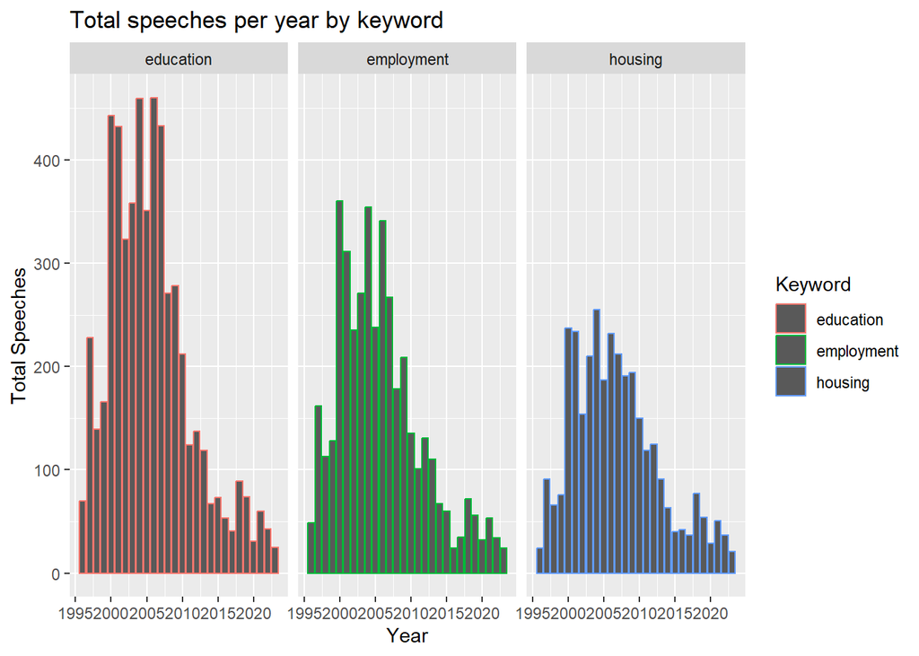

```r
library(tidyverse)
library(rvest)

keywords <- c("education", "employment", "housing")

search1 <- read_html(paste0("https://datalandscapes.online/scrapeable/speeches.php?search=", keywords[1])) %>%
  html_elements(".speech_summary") %>%
  html_text2() %>%
  tibble(keyword = keywords[1],
         results = .) %>%
  separate(results, into = c("year", "num_speeches"), sep = "--") %>%
  mutate(num_speeches = parse_number(num_speeches),
         year = parse_number(year))

search2 <- read_html(paste0("https://datalandscapes.online/scrapeable/speeches.php?search=", keywords[2])) %>%
  html_elements(".speech_summary") %>%
  html_text2() %>%
  tibble(keyword = keywords[2],
         results = .) %>%
  separate(results, into = c("year", "num_speeches"), sep = "--") %>%
  mutate(num_speeches = parse_number(num_speeches),
         year = parse_number(year))

search3 <- read_html(paste0("https://datalandscapes.online/scrapeable/speeches.php?search=", keywords[3])) %>%
  html_elements(".speech_summary") %>%
  html_text2() %>%
  tibble(keyword = keywords[3],
         results = .) %>%
  separate(results, into = c("year", "num_speeches"), sep = "--") %>%
  mutate(num_speeches = parse_number(num_speeches),
         year = parse_number(year))

combined_search <- bind_rows(search1, search2, search3)

speeches_governments <- read_csv("https://docs.google.com/spreadsheets/d/e/2PACX-1vRHTFJcFmsIkjaFUCEwFWASaBOAR4X2Upx66C5Bhgc_WNc2JxxdRbbvyoewmvt_EjNdCNZZzzkENwLg/pub?gid=0&single=true&output=csv")

speech_data <- inner_join(combined_search, speeches_governments, by = "year")
plot_data <- speech_data %>% group_by(year, keyword) %>% summarise(total = sum(num_speeches), .groups="keep") %>% tibble()

ggplot(plot_data) +
  geom_col(aes(x = year,
                 y = total,
                 colour = keyword)) +
  facet_wrap(vars(keyword)) + labs(x="Year", y="Total Speeches", title="Total speeches per year by keyword", color="Keyword")
```

## Learning reflection

I learnt how to be able to tell whether a website allows web scraping, which I think is super important because I had no idea that most websites have their own robots.txt file and it’s useful knowledge. It also gives insight into how various sites are responding to ChatGPT, as most of the robots.txt files I found had ChatGPT explicitly blocked. Web scraping is an extremely useful tool as well, that I had no idea how to do, and this gives me insight into how data is collected for analysis off of the web without having access to the websites’ databases directly. I am curious about exploring further what uses web scraping will have to my own life, and how people combat it when people ignore their robots.txt and ToS.

## Self review

I think the amount of practice with RMarkdown and its versatility has been extremely useful for me, as I had no idea there was such a versatile tool for combining R code, markdown and HTML/CSS built in anywhere - the results it produces so easily seem like they should take a lot more work than they do. This relates to the course learning outcome: “Develop communication skills, including using reproducible reporting with R Markdown”, which I think having to produce a report for each project has definitely developed for me. In addition, another communication skill this course has taught me has been how best to summarise and display data, which is definitely not something I was gifted at before, and I’ve been given a lot of direction and practice in what considerations there are when communicating data that I did not previously have.